# Sentiment Classification

## Loading the dataset

```python
from keras.datasets import imdb
vocab_size = 10000 #vocab size
(x_train, y_train), (x_test, y_test) = imdb.load_data(num_words=vocab_size) # vocab_size is no.of words to consider from the dataset, ordering based on frequency.
```

```python
from keras.preprocessing.sequence import pad_sequences
vocab_size = 10000 #vocab size
maxlen = 300  #number of word used from each review
embedding_dim = 300 #embedding dimensions
```

## Train test split

```python
#load dataset as a list of ints
(x_train, y_train), (x_test, y_test) = imdb.load_data(num_words=vocab_size)
#make all sequences of the same length
x_train = pad_sequences(x_train, maxlen=maxlen)
x_test =  pad_sequences(x_test, maxlen=maxlen)
```

```
findfont: Font family ['sans-serif'] not found. Falling back to DejaVu Sans.
findfont: Font family ['sans-serif'] not found. Falling back to DejaVu Sans.
```

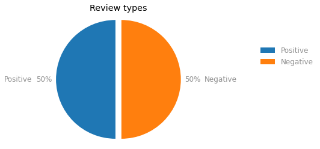

```python
%matplotlib inline
import matplotlib.pyplot as plt #import matplotib
import numpy as np#import numpy

#plot to visualize sentiment percentages in dataset
fig, ax = plt.subplots()
plt.rcParams['font.sans-serif'] = 'Arial'
plt.rcParams['font.family'] = 'sans-serif'
plt.rcParams['text.color'] = '#909090'
plt.rcParams['axes.labelcolor']= '#909090'
plt.rcParams['xtick.color'] = '#909090'
plt.rcParams['ytick.color'] = '#909090'
plt.rcParams['font.size']=12

labels = ['Positive', 'Negative']
explode=(0.1,0)
unique, counts = np.unique(np.concatenate((y_train, y_test)), return_counts=True)
ax.pie(counts, explode=explode, labels=labels,
       autopct='%1.0f%%',
       shadow=False, startangle=90,
       pctdistance=1.2,labeldistance=1.4)
ax.axis('equal')
ax.set_title("Review types")
ax.legend(frameon=False, bbox_to_anchor=(1.5,0.8))
```

## Build Keras Embedding Layer Model

We can think of the Embedding layer as a dicionary that maps a index assigned to a word to a word vector. This layer is very flexible and can be used in a few ways:

- The embedding layer can be used at the start of a larger deep learning model.
- Also we could load pre-train word embeddings into the embedding layer when we create our model.
- Use the embedding layer to train our own word2vec models.

The keras embedding layer doesn't require us to onehot encode our words, instead we have to give each word a unqiue intger number as an id. For the imdb dataset we've loaded this has already been done, but if this wasn't the case we could use sklearn [LabelEncoder](http://scikit-learn.org/stable/modules/generated/sklearn.preprocessing.LabelEncoder.html).

```python
import keras.backend as K #import keras
from keras.models import Sequential #import sequential model
from keras.layers import Embedding, LSTM, Dense, Dropout, Flatten, Conv1D, MaxPooling1D, Bidirectional,LeakyReLU,Activation #import layers
from keras.constraints import max_norm, unit_norm #import normalization constraints
from sklearn.metrics import classification_report, confusion_matrix, accuracy_score #import scoring metrics
```

## Basic Neural Network

```python
model_NN = Sequential() #sequential model
model_NN.add(Embedding(input_dim=vocab_size,output_dim=embedding_dim,input_length=maxlen)) #embedding layer
model_NN.add(Flatten()) #flatten
model_NN.add(Dense(300, activation='relu')) #dense layer
model_NN.add(Dense(1,activation='sigmoid')) #dense layer
model_NN.summary() #model summary
```

```
Model: "sequential_1"
_________________________________________________________________
Layer (type)                 Output Shape              Param #
=================================================================
embedding_1 (Embedding)      (None, 300, 300)          3000000
_________________________________________________________________
flatten_1 (Flatten)          (None, 90000)             0
_________________________________________________________________
dense_1 (Dense)              (None, 300)               27000300
_________________________________________________________________
dense_2 (Dense)              (None, 1)                 301
=================================================================
Total params: 30,000,601
Trainable params: 30,000,601
Non-trainable params: 0
_________________________________________________________________
```

```python
model_NN.compile(optimizer='adam',metrics=['accuracy'],loss='binary_crossentropy') #compile
```

```python
model_H = model_NN.fit(x_train,y_train,epochs=5,batch_size=512,validation_split=0.2) #fit model and create history object
```

```
Train on 20000 samples, validate on 5000 samples
```

```python
y_pred = model_NN.predict_classes(x_test) #predict test data

print('\033[1m''->'*63)
print('\033[1m''Confusion Matrix\n',confusion_matrix(y_test,y_pred)) #for confusion matrix
print('-'*30)
loss, accuracy = model_NN.evaluate(x_test, y_test) #evaluate
loss = loss * 100 #loss in percentage
accuracy = accuracy * 100 #accuracy in percentage
print('Neural Network Accuracy: {:.2f}% & Loss {:.2f}%' .format(accuracy,loss)) #print accuracy and loss
print('-'*30)
print('\n Classification Report\n',classification_report(y_test,y_pred)) #for classification report
print('->'*63)
```

```
->->->->->->->->->->->->->->->->->->->->->->->->->->->->->->->->->->->->->->->->->->->->->->->->->->->->->->->->->->->->->->->
Confusion Matrix
 [[10909  1591]
 [ 1611 10889]]
------------------------------
Neural Network Accuracy: 87.19% & Loss 38.17%
------------------------------

 Classification Report
               precision    recall  f1-score   support

           0       0.87      0.87      0.87     12500
           1       0.87      0.87      0.87     12500

    accuracy                           0.87     25000
   macro avg       0.87      0.87      0.87     25000
weighted avg       0.87      0.87      0.87     25000

->->->->->->->->->->->->->->->->->->->->->->->->->->->->->->->->->->->->->->->->->->->->->->->->->->->->->->->->->->->->->->->
```

```
findfont: Font family ['sans-serif'] not found. Falling back to DejaVu Sans.
findfont: Font family ['sans-serif'] not found. Falling back to DejaVu Sans.
```

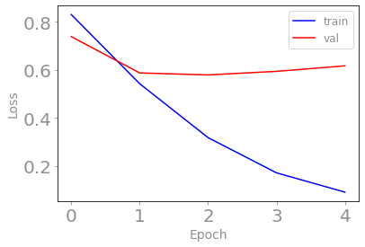

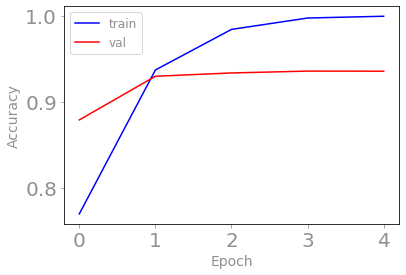

```python
# Plot the loss function
fig, ax = plt.subplots(1, 1, figsize=(6,4)) #create subplot
ax.plot(np.sqrt(model_H.history['loss']), 'b', label='train') #plot training loss
ax.plot(np.sqrt(model_H.history['val_loss']), 'r' ,label='val') #plot validation loss
ax.set_xlabel(r'Epoch', fontsize=14) #set xlabel
ax.set_ylabel(r'Loss', fontsize=14) #set ylabel
ax.legend() #legend
ax.tick_params(labelsize=20) #set label size

# Plot the accuracy
fig, ax = plt.subplots(1, 1, figsize=(6,4)) #create subplot
ax.plot(np.sqrt(model_H.history['accuracy']), 'b', label='train') #plot training accuracy
ax.plot(np.sqrt(model_H.history['val_accuracy']), 'r' ,label='val') #plot validation accuracy
ax.set_xlabel(r'Epoch', fontsize=14) #set xlabel
ax.set_ylabel(r'Accuracy', fontsize=14) #set ylabel
ax.legend() #legend
ax.tick_params(labelsize=20) #set label size
```

## Convolutional Neural Network

- Following Convolutional Network has 1 input layer(Embedding layer), 2 dropout layers, 1 Convolution and 1 Maxpool layer and 2 fully connected layers to predict sentiment(Positive/Negative).

```python
model_CNN = Sequential() #sequential model
model_CNN.add(Embedding(input_dim=vocab_size,output_dim=embedding_dim,input_length=maxlen)) #embedding layer
model_CNN.add(Dropout(0.2)) #dropout layer
model_CNN.add(Conv1D(filters=32,kernel_size=3,padding='same', activation='relu')) #convolution layer
model_CNN.add(MaxPooling1D()) #maxpooling layer
model_CNN.add(Dropout(0.2)) #dropout layer
model_CNN.add(Flatten()) #flatten layer
model_CNN.add(Dense(300, activation='relu')) #dense layer
model_CNN.add(Dense(1,activation='sigmoid')) #dense layer
model_CNN.summary() #summary
```

```
Model: "sequential_2"
_________________________________________________________________
Layer (type)                 Output Shape              Param #
=================================================================
embedding_2 (Embedding)      (None, 300, 300)          3000000
_________________________________________________________________
dropout_1 (Dropout)          (None, 300, 300)          0
_________________________________________________________________
conv1d_1 (Conv1D)            (None, 300, 32)           28832
_________________________________________________________________
max_pooling1d_1 (MaxPooling1 (None, 150, 32)           0
_________________________________________________________________
dropout_2 (Dropout)          (None, 150, 32)           0
_________________________________________________________________
flatten_2 (Flatten)          (None, 4800)              0
_________________________________________________________________
dense_3 (Dense)              (None, 300)               1440300
_________________________________________________________________
dense_4 (Dense)              (None, 1)                 301
=================================================================
Total params: 4,469,433
Trainable params: 4,469,433
Non-trainable params: 0
_________________________________________________________________
```

```python
model_CNN.compile(optimizer='adam',metrics=['accuracy'],loss='binary_crossentropy') #compile
```

```python
modelCNN_H = model_CNN.fit(x_train,y_train,epochs=5,batch_size=512,validation_split=0.2,verbose=0) #fit model and create history object
```

```python
y_pred = model_CNN.predict_classes(x_test) #predict test data

print('\033[1m''->'*63)
print('\033[1m''Confusion Matrix\n',confusion_matrix(y_test,y_pred)) #for confusion matrix
print('-'*30)
loss, accuracy = model_NN.evaluate(x_test, y_test,verbose=0)#evaluate
loss = loss * 100 #loss in percentage
accuracy = accuracy * 100 #accuracy in percentage
print('Convolutional Neural Network Accuracy: {:.2f}% & Loss {:.2f}%' .format(accuracy,loss)) #print accuracy and loss
print('-'*30)
print('\n Classification Report\n',classification_report(y_test,y_pred)) #for classification report
print('->'*63)
```

```
->->->->->->->->->->->->->->->->->->->->->->->->->->->->->->->->->->->->->->->->->->->->->->->->->->->->->->->->->->->->->->->
Confusion Matrix
 [[11216  1284]
 [ 1957 10543]]
------------------------------
Convolutional Neural Network Accuracy: 87.19% & Loss 38.17%
------------------------------

 Classification Report
               precision    recall  f1-score   support

           0       0.85      0.90      0.87     12500
           1       0.89      0.84      0.87     12500

    accuracy                           0.87     25000
   macro avg       0.87      0.87      0.87     25000
weighted avg       0.87      0.87      0.87     25000

->->->->->->->->->->->->->->->->->->->->->->->->->->->->->->->->->->->->->->->->->->->->->->->->->->->->->->->->->->->->->->->
```

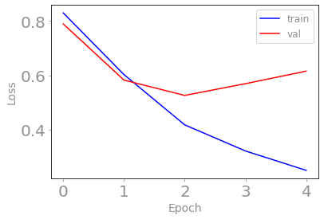

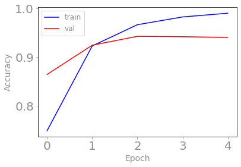

```python
# Plot the loss function
fig, ax = plt.subplots(1, 1, figsize=(6,4)) #create subplot
ax.plot(np.sqrt(modelCNN_H.history['loss']), 'b', label='train') #plot training loss
ax.plot(np.sqrt(modelCNN_H.history['val_loss']), 'r' ,label='val') #plot validation loss
ax.set_xlabel(r'Epoch', fontsize=14) #set xlabel
ax.set_ylabel(r'Loss', fontsize=14) #set ylabel
ax.legend() #legend
ax.tick_params(labelsize=20) #set label size

# Plot the accuracy
fig, ax = plt.subplots(1, 1, figsize=(6,4)) #create subplot
ax.plot(np.sqrt(modelCNN_H.history['accuracy']), 'b', label='train') #plot training accuracy
ax.plot(np.sqrt(modelCNN_H.history['val_accuracy']), 'r' ,label='val') #plot validation accuracy
ax.set_xlabel(r'Epoch', fontsize=14) #set xlabel
ax.set_ylabel(r'Accuracy', fontsize=14) #set ylabel
ax.legend() #legend
ax.tick_params(labelsize=20) #set label size
```

## LSTM

### Forward LSTM Network

- Following forward LSTM Network has 1 input layer(Embedding layer), 1 LSTM layer, 1 Dense, 1 Dropout and 1 fully connected layer to predict sentiment(Positive/Negative).

```python
modelLSTM = Sequential() #sequential model
modelLSTM.add(Embedding(input_dim=vocab_size,output_dim=embedding_dim,input_length=maxlen)) #Embedding layer
modelLSTM.add(LSTM(300, activation='tanh', dropout=0.2,kernel_constraint=unit_norm(),
                   recurrent_constraint=unit_norm(),bias_constraint=unit_norm())) #LSTM layer
modelLSTM.add(Dense(300,activation='relu')) #Dense layer
modelLSTM.add(Dropout(0.2)) #Dropout
modelLSTM.add(Dense(1,activation='sigmoid')) #Dense layer
modelLSTM.summary() #summary
```

```
Model: "sequential_3"
_________________________________________________________________
Layer (type)                 Output Shape              Param #
=================================================================
embedding_3 (Embedding)      (None, 300, 300)          3000000
_________________________________________________________________
lstm_1 (LSTM)                (None, 300)               721200
_________________________________________________________________
dense_5 (Dense)              (None, 300)               90300
_________________________________________________________________
dropout_3 (Dropout)          (None, 300)               0
_________________________________________________________________
dense_6 (Dense)              (None, 1)                 301
=================================================================
Total params: 3,811,801
Trainable params: 3,811,801
Non-trainable params: 0
_________________________________________________________________
```

```python
modelLSTM.compile(optimizer='adam', loss='binary_crossentropy', metrics=['accuracy'])#compile
```

```python
modelLSTM_H = modelLSTM.fit(x_train,y_train,epochs=5,batch_size=512,validation_split=0.2,verbose=1)#fit model and create history object
```

```
Train on 20000 samples, validate on 5000 samples
```

```python
y_pred = modelLSTM.predict_classes(x_test) #predict test data

print('\033[1m''->'*63)
print('\033[1m''Confusion Matrix\n',confusion_matrix(y_test,y_pred)) #for confusion matrix
print('-'*30)
loss, accuracy = modelLSTM.evaluate(x_test, y_test,verbose=0)#evaluate
loss = loss * 100 #loss in percentage
accuracy = accuracy * 100 #accuracy in percentage
print('Forward LSTM Accuracy: {:.2f}% & Loss {:.2f}%' .format(accuracy,loss)) #print accuracy and loss
print('-'*30)
print('\n Classification Report\n',classification_report(y_test,y_pred)) #for classification report
print('->'*63)
```

```
->->->->->->->->->->->->->->->->->->->->->->->->->->->->->->->->->->->->->->->->->->->->->->->->->->->->->->->->->->->->->->->
Confusion Matrix
 [[11427  1073]
 [ 2962  9538]]
------------------------------
Forward LSTM Accuracy: 83.86% & Loss 44.62%
------------------------------

 Classification Report
               precision    recall  f1-score   support

           0       0.79      0.91      0.85     12500
           1       0.90      0.76      0.83     12500

    accuracy                           0.84     25000
   macro avg       0.85      0.84      0.84     25000
weighted avg       0.85      0.84      0.84     25000

->->->->->->->->->->->->->->->->->->->->->->->->->->->->->->->->->->->->->->->->->->->->->->->->->->->->->->->->->->->->->->->
```

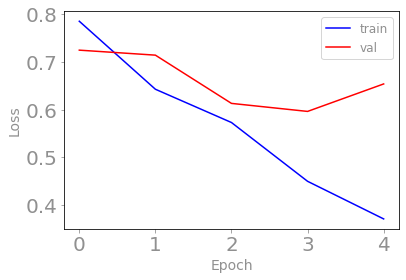

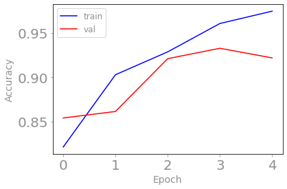

```python
# Plot the loss function
fig, ax = plt.subplots(1, 1, figsize=(6,4)) #create subplot
ax.plot(np.sqrt(modelLSTM_H.history['loss']), 'b', label='train') #plot training loss
ax.plot(np.sqrt(modelLSTM_H.history['val_loss']), 'r' ,label='val')#plot validation loss
ax.set_xlabel(r'Epoch', fontsize=14)#set xlabel
ax.set_ylabel(r'Loss', fontsize=14)#set ylabel
ax.legend() #legend
ax.tick_params(labelsize=20) #set label size

# Plot the accuracy
fig, ax = plt.subplots(1, 1, figsize=(6,4))#create subplot
ax.plot(np.sqrt(modelLSTM_H.history['accuracy']), 'b', label='train')#plot training accuracy
ax.plot(np.sqrt(modelLSTM_H.history['val_accuracy']), 'r' ,label='val')#plot validation accuracy
ax.set_xlabel(r'Epoch', fontsize=14)#set xlabel
ax.set_ylabel(r'Accuracy', fontsize=14)#set ylabel
ax.legend()#legend
ax.tick_params(labelsize=20)#set label size
```

### Bidirectional LSTM Network

```python
modelBiDiLSTM = Sequential()
modelBiDiLSTM.add(Embedding(input_dim=vocab_size,output_dim=embedding_dim,input_length=maxlen))
modelBiDiLSTM.add(Bidirectional(LSTM(300, activation='tanh', dropout=0.2,kernel_constraint=unit_norm(),
                                 recurrent_constraint=unit_norm(),bias_constraint=unit_norm())))
modelBiDiLSTM.add(Dropout(0.3))
modelBiDiLSTM.add(Dense(300,activation='relu'))
modelBiDiLSTM.add(Dropout(0.3))
modelBiDiLSTM.add(Dense(1,activation='sigmoid'))
modelBiDiLSTM.summary()
```

```
Model: "sequential_4"
_________________________________________________________________
Layer (type)                 Output Shape              Param #
=================================================================
embedding_4 (Embedding)      (None, 300, 300)          3000000
_________________________________________________________________
bidirectional_1 (Bidirection (None, 600)               1442400
_________________________________________________________________
dropout_4 (Dropout)          (None, 600)               0
_________________________________________________________________
dense_7 (Dense)              (None, 300)               180300
_________________________________________________________________
dropout_5 (Dropout)          (None, 300)               0
_________________________________________________________________
dense_8 (Dense)              (None, 1)                 301
=================================================================
Total params: 4,623,001
Trainable params: 4,623,001
Non-trainable params: 0
_________________________________________________________________
```

```python
modelBiDiLSTM.compile(optimizer='adam', loss='binary_crossentropy', metrics=['accuracy'])#compile
```

```python
modelBiDiLSTM_H = modelBiDiLSTM.fit(x_train,y_train,epochs=5,batch_size=512,validation_split=0.2,verbose=1) #fit model and create history object
```

```
Train on 20000 samples, validate on 5000 samples
```

```python
y_pred = modelBiDiLSTM.predict_classes(x_test) #predict test data

print('\033[1m''->'*63)
print('\033[1m''Confusion Matrix\n',confusion_matrix(y_test,y_pred)) #for confusion matrix
print('-'*30)
loss, accuracy = modelBiDiLSTM.evaluate(x_test, y_test,verbose=0)#evaluate
loss = loss * 100 #loss in percentage
accuracy = accuracy * 100 #accuracy in percentage
print('BiDirectional LSTM Accuracy: {:.2f}% & Loss {:.2f}%' .format(accuracy,loss)) #print accuracy and loss
print('-'*30)
print('\n Classification Report\n',classification_report(y_test,y_pred)) #for classification report
print('->'*63)
```

```
->->->->->->->->->->->->->->->->->->->->->->->->->->->->->->->->->->->->->->->->->->->->->->->->->->->->->->->->->->->->->->->
Confusion Matrix
 [[11422  1078]
 [ 2805  9695]]
------------------------------
BiDirectional LSTM Accuracy: 84.47% & Loss 55.12%
------------------------------

 Classification Report
               precision    recall  f1-score   support

           0       0.80      0.91      0.85     12500
           1       0.90      0.78      0.83     12500

    accuracy                           0.84     25000
   macro avg       0.85      0.84      0.84     25000
weighted avg       0.85      0.84      0.84     25000

->->->->->->->->->->->->->->->->->->->->->->->->->->->->->->->->->->->->->->->->->->->->->->->->->->->->->->->->->->->->->->->
```

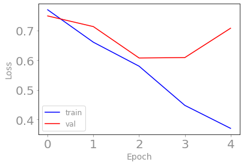

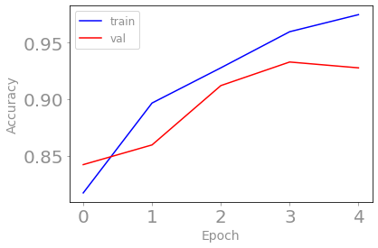

```python
# Plot the loss function
fig, ax = plt.subplots(1, 1, figsize=(6,4)) #create subplot
ax.plot(np.sqrt(modelBiDiLSTM_H.history['loss']), 'b', label='train') #plot training loss
ax.plot(np.sqrt(modelBiDiLSTM_H.history['val_loss']), 'r' ,label='val')#plot validation loss
ax.set_xlabel(r'Epoch', fontsize=14)#set xlabel
ax.set_ylabel(r'Loss', fontsize=14)#set ylabel
ax.legend() #legend
ax.tick_params(labelsize=20) #set label size

# Plot the accuracy
fig, ax = plt.subplots(1, 1, figsize=(6,4))#create subplot
ax.plot(np.sqrt(modelBiDiLSTM_H.history['accuracy']), 'b', label='train')#plot training accuracy
ax.plot(np.sqrt(modelBiDiLSTM_H.history['val_accuracy']), 'r' ,label='val')#plot validation accuracy
ax.set_xlabel(r'Epoch', fontsize=14)#set xlabel
ax.set_ylabel(r'Accuracy', fontsize=14)#set ylabel
ax.legend()#legend
ax.tick_params(labelsize=20)#set label size
```

## Retrive the output of each layer in keras for a given single test sample from the trained model you built

- Following function is used for retrieving layer wise output Tensor for a single instance.
- K.function and K.learning_phase() methods are used for the extraction of output tensor for a single iteration of BiDirectional LSTM algorithm.
- The instance is chosen at random from test data.

```python
def layer_output(model, data):
    layer_outputs = [layer.output for layer in model.layers] #layerwise outputs
    function = K.function([model.input, K.learning_phase()], layer_outputs)

    if data.any():
        print_layer_outputs = function([np.array([data,]), 1])
        print('*'*80)
        for ids, output in enumerate(print_layer_outputs):
            print('\033[1m Layer :', ids + 1.)
            print('\033[1m Layer_Name   :', model.layers[ids].name)
            print('\033[1m Layer_Shape  : ' + str(output.shape))
            print('-'*75)
            print('\033[1m Layer Output Tensor :')
            print(output)
            print('*'*80)
```

```python
instance = np.random.choice(len(x_test))
layer_output(modelBiDiLSTM, x_test[instance])
```

```
 Layer : 1.0
 Layer_Name   : embedding_4
 Layer_Shape  : (1, 300, 300)
---------------------------------------------------------------------------
 Layer Output Tensor :
[[[-0.02826249 -0.00078846  0.00442477 ...  0.04671142 -0.02544079
    0.00785471]
  [-0.02826249 -0.00078846  0.00442477 ...  0.04671142 -0.02544079
    0.00785471]
  [-0.02826249 -0.00078846  0.00442477 ...  0.04671142 -0.02544079
    0.00785471]
  ...
  [-0.01005274 -0.04362317  0.00442694 ...  0.02390516  0.02937017
   -0.05444075]
  [-0.05291583  0.00403456 -0.00041179 ...  0.03306141 -0.04378002
    0.01098438]
  [ 0.016321    0.0082671   0.02468743 ...  0.04946523  0.02062685
   -0.02976272]]]
 Layer : 2.0
 Layer_Name   : bidirectional_1
 Layer_Shape  : (1, 600)
---------------------------------------------------------------------------
 Layer Output Tensor :
[[-6.62060920e-04  6.05696030e-02  5.11762761e-02  7.60490773e-03
   1.00042447e-01 -2.38262508e-02  4.47599553e-02 -8.51867646e-02
   4.37356494e-02  7.79667050e-02 -2.78076585e-02 -8.02525952e-02
   1.30978569e-01  8.28295574e-02 -4.95416336e-02  1.59346201e-02
   1.41704798e-01  8.47583264e-03  5.42828515e-02  2.93561667e-02
  -1.25026088e-02 -5.04709519e-02  4.43706736e-02 -9.28576812e-02
   7.64604509e-02 -4.16839421e-02  2.89516635e-02  6.48204088e-02
  -6.10905467e-03  1.83824766e-02  4.75528613e-02 -5.69966808e-02
   5.98680861e-02 -1.21099539e-01  6.10452890e-02  2.43764743e-03
   1.23255197e-02  5.39765358e-02  6.45769909e-02  1.61726996e-01
  -1.58736378e-01  3.81317772e-02  1.80410281e-01  6.39999509e-02
  -1.91595014e-02  3.71608511e-02  1.40545607e-01 -2.15176269e-01
   9.64084119e-02  8.24977830e-02 -2.83951815e-02  6.03408627e-02
  -7.95199201e-02 -6.61456734e-02 -7.78708383e-02 -3.28788161e-02
  -2.26276573e-02  1.19567886e-01  5.18115517e-03  2.26466674e-02
  -4.58714925e-02 -1.78325102e-02  3.03193294e-02  4.41748239e-02
  -6.41792566e-02  6.53018206e-02  6.10536709e-02  1.38081424e-02
```

[output cut: 389 more lines]

```
  0.         0.         0.         0.         0.44941145 0.
  0.         0.         0.         0.         0.         0.57647806
  0.40332115 0.         0.44157624 0.26648486 0.36213863 0.5418539
  0.         0.         0.         0.         0.         0.4971787
  0.506061   0.         0.13906124 0.3812047  0.41734585 0.
  0.         0.36767918 0.         0.         0.         0.
  0.39295575 0.6730239  0.21759957 0.         0.         0.43713897
  0.         0.         0.16536789 0.22165029 0.         0.48148885
  0.         0.3996254  0.66885585 0.         0.50054336 0.        ]]
 Layer : 6.0
 Layer_Name   : dense_8
 Layer_Shape  : (1, 1)
---------------------------------------------------------------------------
 Layer Output Tensor :
[[0.98943347]]
```